# Relatório Projeto Estatística

Juliana Andresa Vieira de Lima

25/01/2023

## Importando bibliotecas

```r
library(readxl)
library(magrittr)
library(dplyr)
library(ggplot2)
library(tidyverse)
```

## Importando o arquivo de xlsx “sp_beaches”

Importei o arquivo do excel utilizando a função `read_excel`. Dentro da função passei o caminho da pasta onde meu projeto está armazenado.

`df_beaches=read_excel(path = "C:/Users/julia/OneDrive/Documentos/Juliana/EstatisticaProjeto/sp_beaches.xlsx")`

### Filtrando cidade Peruíbe

- Usando a função `filter` foi realizado o filtro da tabela `df_beaches`. Criei uma tabela de nome `filtrados` para armazenar apenas os dados referente á **Cidade de Peruíbe**.
- No mesmo código utilizei a função `mutate` e `as.numeric` modificando o **Enterococcus** para números inteiros.  
  **Veja a tabela a seguir :**

| City | Beach | Date | Enterococcus |
| --- | --- | --- | --- |
| PERUÍBE | PERUÍBE (R. ICARAÍBA) | 2012-01-03 | 5 |
| PERUÍBE | PERUÍBE (R. ICARAÍBA) | 2012-01-08 | 13 |
| PERUÍBE | PERUÍBE (R. ICARAÍBA) | 2012-01-15 | 1 |
| PERUÍBE | PERUÍBE (R. ICARAÍBA) | 2012-01-22 | 36 |
| PERUÍBE | PERUÍBE (R. ICARAÍBA) | 2012-01-29 | 10 |
| PERUÍBE | PERUÍBE (R. ICARAÍBA) | 2012-02-05 | 5 |
| PERUÍBE | PERUÍBE (R. ICARAÍBA) | 2012-02-12 | 272 |
| PERUÍBE | PERUÍBE (R. ICARAÍBA) | 2012-02-19 | 32 |
| PERUÍBE | PERUÍBE (R. ICARAÍBA) | 2012-02-26 | 1 |
| PERUÍBE | PERUÍBE (R. ICARAÍBA) | 2012-03-04 | 10 |

[output cut: 2715 more lines]

## 1ª Questão:

- Criei uma tabela chamada `peruibe` para agrupar meus dados por praia. Todos os dados foram provenientes da tabela *filtrados*
- A tabela foi composta dos seguintes cálculos para cada praia:
  - **Média:** função `mean`
  - **Desvio-padrão:** função `sd`
  - **Mediana:** função `median`
  - **Q1:** função `quantile` + `probs = 0.25`, primeiro quartil referente á 25% dos dados
  - **Q3:** função `quantile` + `probs = 0.75`, terceiro quartil referente á 75% dos dados
  - **Mínimo:** função `min`
  - **Máximo:** função `max`
- Na mesma tabela adicionei a função `contagem` para facilitar no próximo passo

| Beach | media | desvioPadrao | mediana | q1 | q3 | minimo | maximo | contagem |
| --- | --- | --- | --- | --- | --- | --- | --- | --- |
| GUARAÚ | 42.85135 | 99.55350 | 7 | 2 | 31.25 | 1 | 940 | 444 |
| PERUÍBE (AV. S. JOÃO) | 62.53132 | 112.99670 | 19 | 5 | 80.50 | 1 | 1100 | 463 |
| PERUÍBE (BALN. SÃO JOÃO BATISTA) | 60.48812 | 122.10750 | 14 | 4 | 66.00 | 1 | 1180 | 463 |
| PERUÍBE (PARQUE TURÍSTICO) | 54.52700 | 112.91252 | 12 | 3 | 57.00 | 1 | 1100 | 463 |
| PERUÍBE (R. ICARAÍBA) | 50.78076 | 99.40941 | 12 | 4 | 55.00 | 1 | 840 | 447 |
| PRAINHA | 52.62472 | 111.16606 | 12 | 4 | 51.00 | 1 | 960 | 445 |

**Observações**:  
- A praia de *PERUÍBE (AV. S. JOÃO), PERUÍBE (BALN. SÃO JOÃO BATISTA)* e *PERUÍBE (PARQUE TURÍSTICO)* estão em mesma quantidade, igual a **463**, porém os resultados de **Média**, **Mediana**,**Q1** e **Q3** estão diferentes. Por outro lado o **Desvio- Padrão** se aproxima uma da outra, **Mínimo** são iguais e **Máximo** apenas uma difere das demais.

## 2ª Questão - Gráfico de Barras

- Primeiramente criei a tabela `dados` para armazenar apenas as Praias de Peruíbe, sua respectiva contagem e frequência.
- Para adicionar a frequência na tabela dividi a **contagem** pela **soma das contagens**(`contagem/sum(contagem)`), em seguida utilizei a função `Frequencia = round(Frequencia*100,2)`. Veja a seguir:

| Beach | contagem | Frequencia |
| --- | --- | --- |
| GUARAÚ | 444 | 16.29 |
| PERUÍBE (AV. S. JOÃO) | 463 | 16.99 |
| PERUÍBE (BALN. SÃO JOÃO BATISTA) | 463 | 16.99 |
| PERUÍBE (PARQUE TURÍSTICO) | 463 | 16.99 |
| PERUÍBE (R. ICARAÍBA) | 447 | 16.40 |
| PRAINHA | 445 | 16.33 |

- O gráfico a seguir representa as praias de peruíbe baseadas em maior e menor quantidade de amostras
- As porcentagens significam as frequências da tabela anterior
- É possível observar que praias com igual contagem são definidas pela mesma frequência e quanto menor a contagem menor será sua frequência.

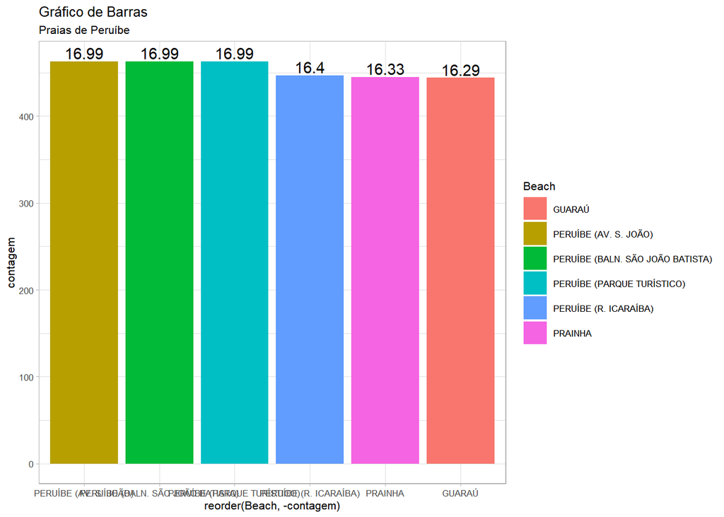

## 3ª Questão - Gráfico de Pizza

- Igual a questão anterior, mas apresentada no formato de gráfico pizza.

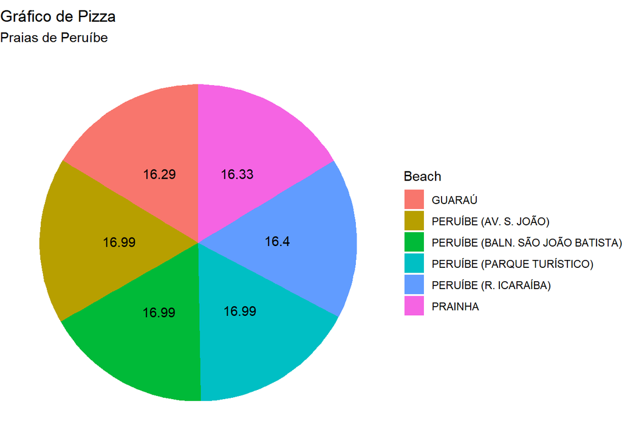

## 4ª Questão - Histograma

- O pico de dados ocorre em cerca de 0 Enterococcus. A dispersão de dados é a partir de cerca de 0 a 1200 Enterococcus.
- Dados assimétricos,indicando que os dados podem não ser normalmente distribuídos.
- Ajuste de distribuição não é bom.

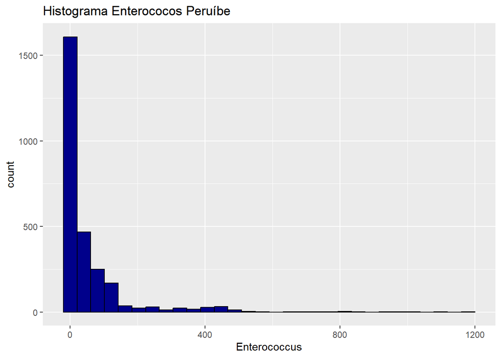

## 5ª Questão - Box-Plot

- De acordo com a disposição do Box-Plot é possível observar que os dados são assimétricos positivos.
- Os valores discrepantes(outliers) são caracterizados por limites superiores, estando acima do limite de detecção de outliers.
- Podemos concluir que a praia de *PERUÍBE (AV. S. JOÃO)* apresenta maior variabilidade do que as outras praias, e a praia de *GUARAÚ* apresenta menor variabilidade.

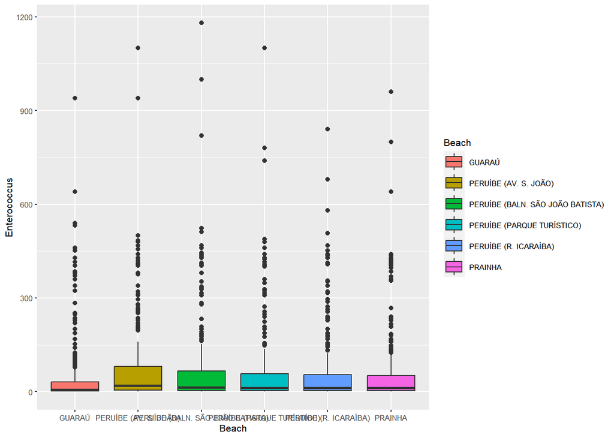